# Assignment 2

Eva Giannatou

December 20, 2016

## Question 1

- 1.1

H0: There is no increase in efficiency (the mean stays the same)

H1: There is an increase in efficiency (the mean increases)

95% confidence interval

Suppose null hypothesis

```r
before <- c(370, 385, 375, 380, 378)
after <- c(387, 397, 380, 392, 389)

m1 <- round(mean(before),2)
mx1 <- round(mean(after),2)

s1 <- round(sd(before),2)
sx1 <- round(sd(after),2)

z <- round((mx1 - m1) / sx1,2)

one_sided_high <- round(pnorm(abs(z), lower.tail = F),2)


t.test(after, before, paired=T, alternative = "greater", conf.level = 0.95)
```

```
##
##  Paired t-test
##
## data:  after and before
## t = 5.9589, df = 4, p-value = 0.001991
## alternative hypothesis: true difference in means is greater than 0
## 95 percent confidence interval:
##  7.321537      Inf
## sample estimates:
## mean of the differences
##                    11.4
```

The probability of getting a result at least so many standard deviations away is 0.03 < alpha=0.05. This result seems to favor the alternative hypothesis, which means that there is probably an efficiency increase.

Moreover according to T-test’ p-value = 0.001991, we reject Ho. The mean increases when the gas additives are used.

- 1.2

H0: Equally divided opinion  
H1: Not equally divided opinion

Suppose null hypothesis

```r
a <- 0.5
pbar <- 110/200
p0 <- 0.5
n <- 200
z <- (pbar-p0)/sqrt(p0*(1-p0)/n)
z
```

```
## [1] 1.414214
```

```r
pval <- 2*pnorm(z, lower.tail=FALSE)
pval
```

```
## [1] 0.1572992
```

Pnorm function computes the two-tailed p-value of the test statistic. It doubles the upper tail p-value as the sample proportion is greater than the hypothesized value. Since p-value > 0.05 significance level, we do not reject the null hypothesis that p = 0.5.

- 1.3

```r
s <- 230
n <- 16
mx <- 1020
a <- 0.02
df <- n - 1
sx <- round(s/sqrt(n))

error <- round(qnorm(0.99)*sx/sqrt(n))
left <- a-error
right <- a+error
left
```

```
## [1] -33.98
```

```r
right
```

```
## [1] 34.02
```

```r
mx+left
```

```
## [1] 986.02
```

```r
mx+right
```

```
## [1] 1054.02
```

The true mean has a probability of 98% of being in the interval between 986 and 1054 squared hours assuming that the original random variable is normally distributed, and the samples are independent.

- 1.4

```r
sx <- 275
n <- 16
mx <- 1020
a <- 0.02
df <- n - 1

error <- round(qnorm(0.99)*sx/sqrt(n))
left <- a-error
right <- a+error
left
```

```
## [1] -159.98
```

```r
right
```

```
## [1] 160.02
```

```r
mx+left
```

```
## [1] 860.02
```

```r
mx+right
```

```
## [1] 1180.02
```

The true mean has a probability of 98% of being in the interval between 860 and 1180 squared hours assuming that the original random variable is normally distributed, and the samples are independent.

- 1.5

H0: at least 90% of the bulbs will bloom

H1: less than 90% of the bulbs will bloom

Suppose null hypothesis

```r
pbar <- 476/500
p0 <- 0.9
n <- 500
z <- (pbar-p0)/sqrt(p0*(1-p0)/n)

pval <- pnorm(z)
pval
```

```
## [1] 0.9999469
```

Since the p-value 0.99 > a = 0.05, we fail to reject H0.

- 1.6

H0: The two samples came from the same distribution

H1: They didn’t come from the same distribution

Suppose null hypothesis

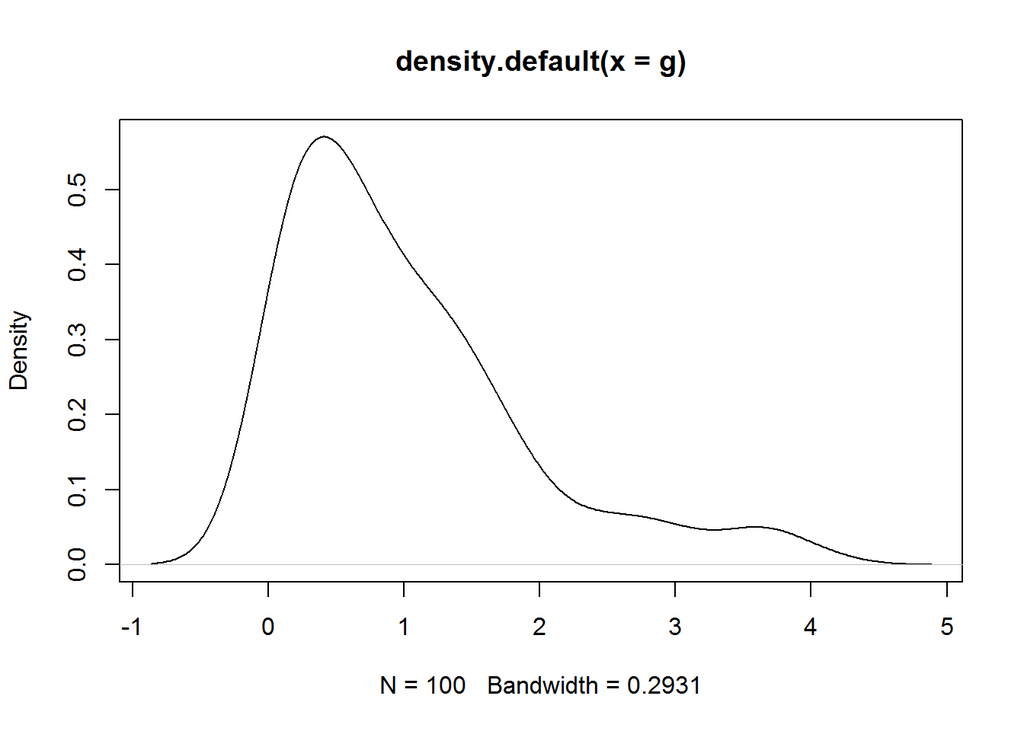

```r
library(ggplot2)
g <- rgamma(100, shape = 1,  scale = 1)
e <- rexp(100, rate = 1)
plot(density(g))
```

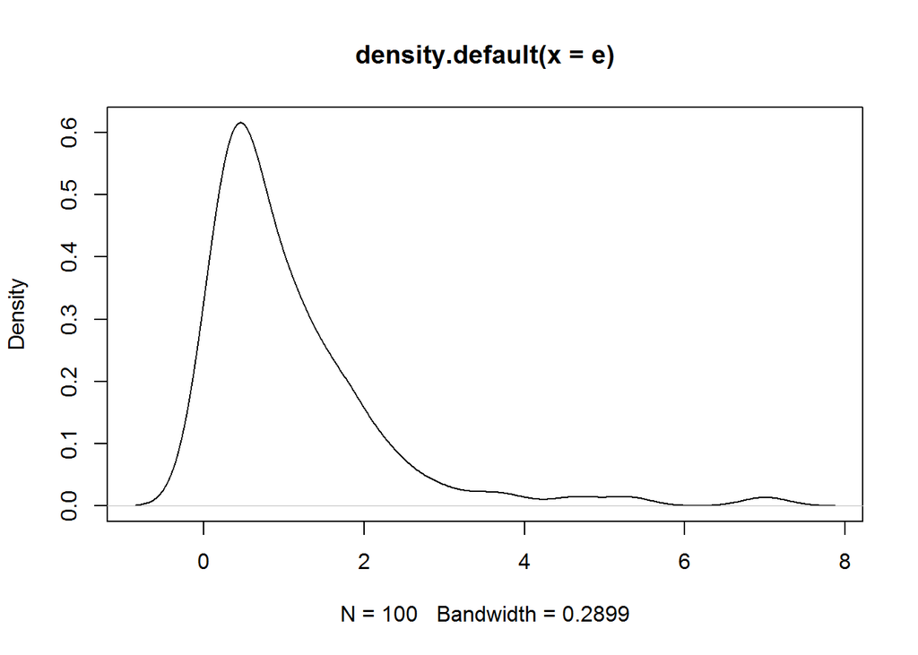

```r
plot(density(e))
```

```r
t.test(g,e, var.equal=TRUE, paired=FALSE)
```

```
##
##  Two Sample t-test
##
## data:  g and e
## t = -0.52952, df = 198, p-value = 0.597
## alternative hypothesis: true difference in means is not equal to 0
## 95 percent confidence interval:
##  -0.3611821  0.2082730
## sample estimates:
## mean of x mean of y
##  1.007331  1.083786
```

We obtained p-value greater than 0.05 and therefore we can conclude that the averages of two groups are significantly similar. This confirms that we can accept the null hypothesis H0. In this case the result is expected beacause the Gamma(1, b) is the Exponential distribution.

- 1.7

H0: m=82

H1: m!=82

Suppose null hypothesis

```r
scores <- c(92, 83, 95, 96, 85, 61, 76, 80, 92, 87)

t.test(scores, mu=82, conf.level = 0.95)
```

```
##
##  One Sample t-test
##
## data:  scores
## t = 0.80674, df = 9, p-value = 0.4406
## alternative hypothesis: true mean is not equal to 82
## 95 percent confidence interval:
##  77.129 92.271
## sample estimates:
## mean of x
##      84.7
```

Since the p-value 0.44 > a = 0.05, we fail to reject H0.

## Question 2

- 2.1 Poisson

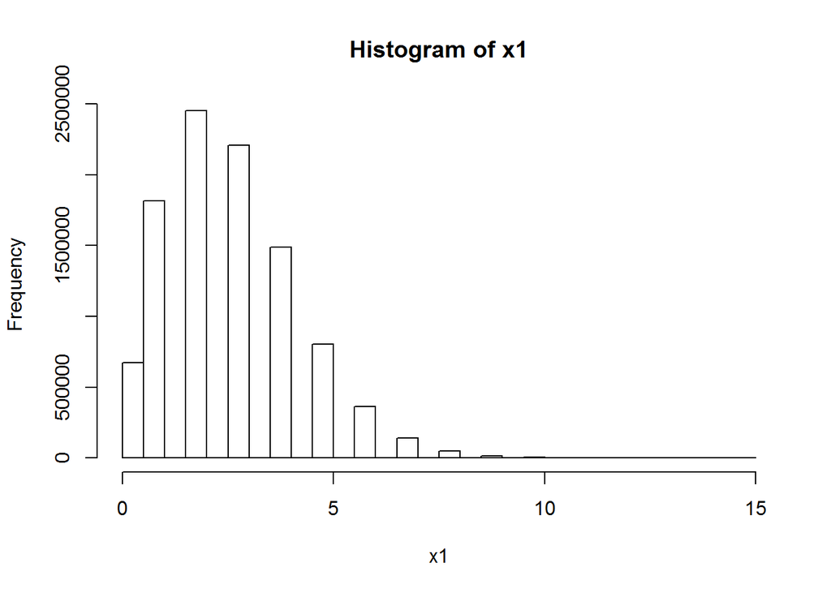

```r
samples <- 10000
size <- 1000

set.seed(0)
x1 <- replicate(samples, rpois(n=size, lambda = 2.7))

hist(x1)
```

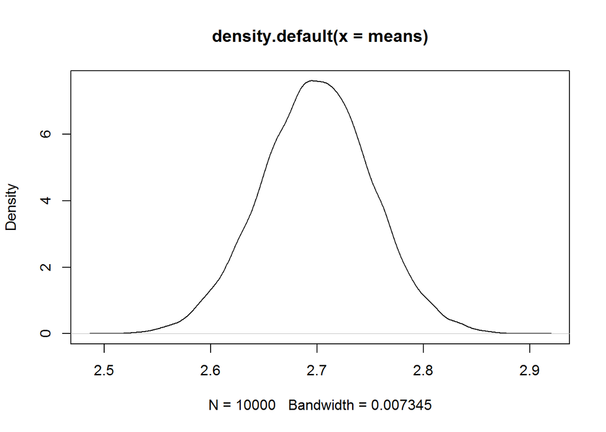

```r
means <- colMeans(x1)

plot(density(means))
```

The density plot of the means seems to follow the normal ditribution. According to the central limit theorem the sampling distribution of the mean of any independent, random variable will be normal or nearly normal, if the sample size is large enough.

```r
mean(means)
```

```
## [1] 2.699473
```

The mean of the sample means is 2.7 which equals to lamda.This is expected, since in the Poisson distribution, the mean E[X]=lamda.

H0: sample means are normally distributed H1: sample means are not normally distributed

suppose H0

```r
ks.test(means,"pnorm",mean(means),sd(means))
```

```
##
##  One-sample Kolmogorov-Smirnov test
##
## data:  means
## D = 0.0092409, p-value = 0.3603
## alternative hypothesis: two-sided
```

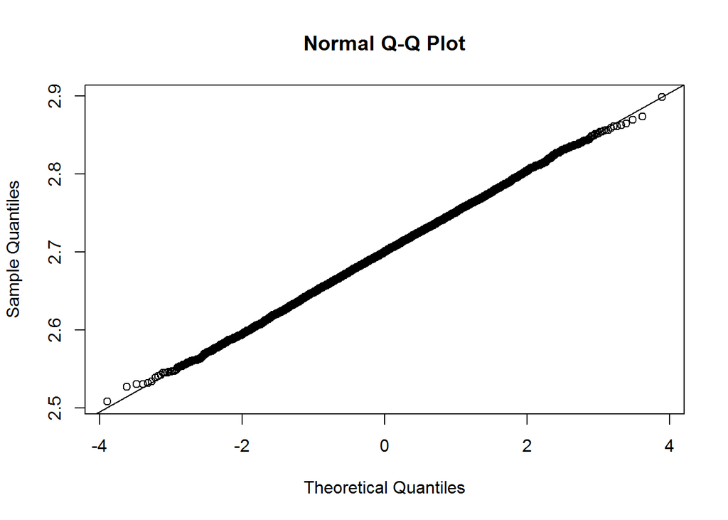

```r
qqnorm(means)
qqline(means)
```

The ks.test eturns the P-value correspoding to the D statistic.The D statistic is the absolute max distance (supremum) between the CDFs of the two samples. The closer this number is to 0 the more likely it is that the two samples were drawn from the same. distribution.

The p-value equals to 0.36 > 0.05 and the maximum distance between the CDFs is really small. Therefore we fail to reject the null hypothesis that the sample means are normally distributed.

- 2.2 Binomial

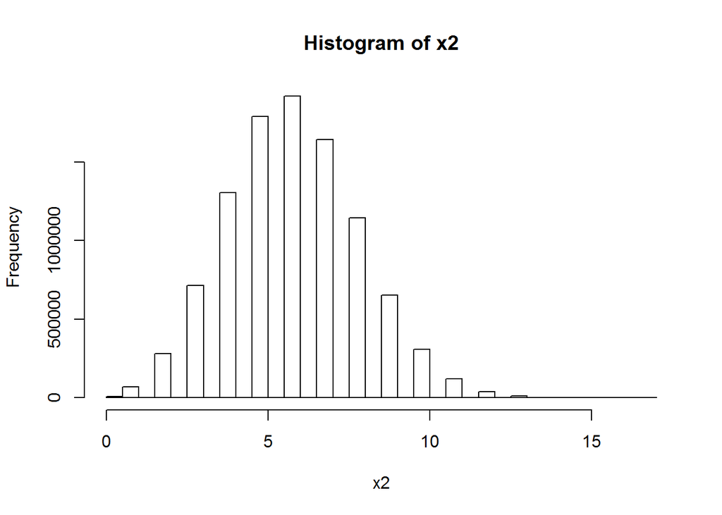

```r
samples <- 10000
size <- 1000

set.seed(0)
x2 <- replicate(samples, rbinom(n=size, size=20, prob = 0.3))


hist(x2)
```

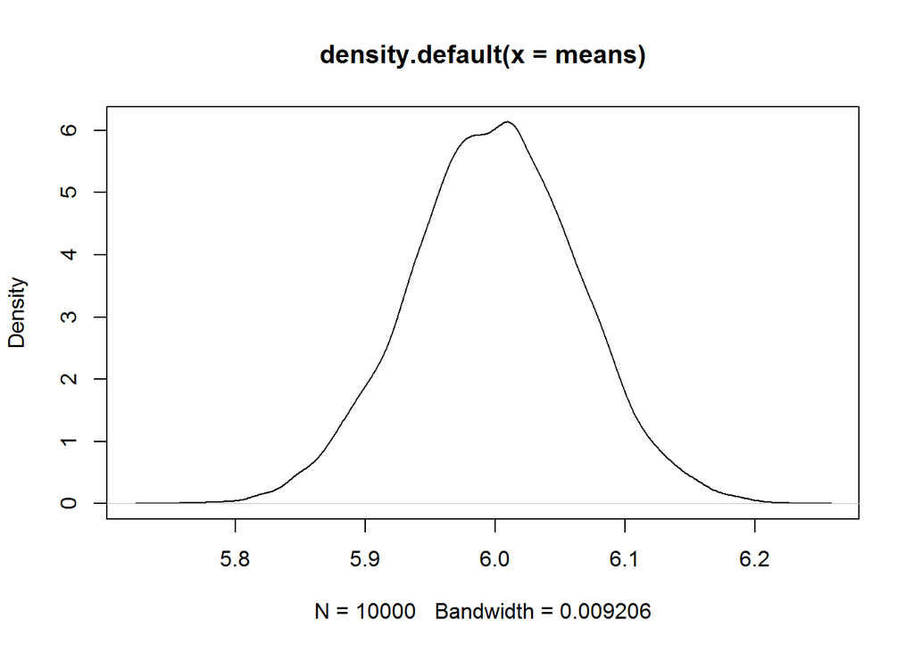

```r
means <- colMeans(x2)

plot(density(means))
```

The density plot of the means seems to follow the normal ditribution. According to the central limit theorem the sampling distribution of the mean of any independent, random variable will be normal or nearly normal, if the sample size is large enough.

```r
mean(means)
```

```
## [1] 5.999114
```

The mean of my sample means is 6 which equals to lamda.This is expected, since in the Binomial distribution, the mean E[X]=np.

H0: sample means are normally distributed H1: sample means are not normally distributed

suppose H0

```r
ks.test(means,"pnorm",mean(means),sd(means))
```

```
##
##  One-sample Kolmogorov-Smirnov test
##
## data:  means
## D = 0.0081568, p-value = 0.5189
## alternative hypothesis: two-sided
```

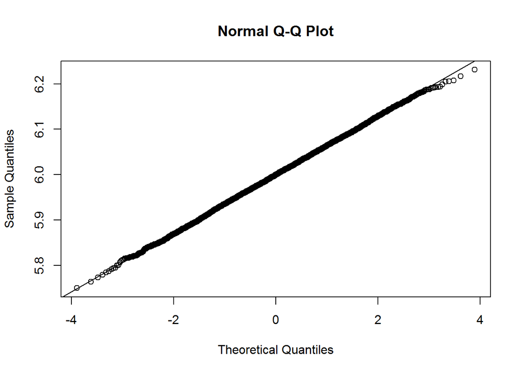

```r
qqnorm(means)
qqline(means)
```

P-value=0.5>a and D = 0.0081568 and therefore we fail to reject the null hypothesis that the sample means are normally distributed. If n is large enough and p not close to 0 or 1, then the distribution appears close to symmetric.

## Question 3

- 3.1

```r
anova_data <- read.csv("./anova_data.csv")

anova <- anova_data
str(anova)
```

```
## 'data.frame':    173 obs. of  17 variables:
##  $ country           : Factor w/ 173 levels "Afghanistan",..: 1 2 3 4 5 6 7 8 9 10 ...
##  $ incomeperperson   : num  NA 1915 2232 1381 10749 ...
##  $ alcconsumption    : num  0.03 7.29 0.69 5.57 9.35 ...
##  $ armedforcesrate   : num  0.57 1.025 2.307 1.461 0.561 ...
##  $ breastcancer      : num  26.8 57.4 23.5 23.1 73.9 51.6 83.2 70.5 31.5 54.4 ...
##  $ co2emissions      : num  7.59e+07 2.24e+08 2.93e+09 2.48e+08 5.87e+09 ...
##  $ femaleemployrate  : num  25.6 42.1 31.7 69.4 45.9 ...
##  $ hivrate           : num  NA NA 0.1 2 0.5 0.1 0.1 0.3 0.1 3.1 ...
##  $ internetuserate   : num  3.65 44.99 12.5 10 36 ...
##  $ lifeexpectancy    : num  48.7 76.9 73.1 51.1 75.9 ...
##  $ oilperperson      : num  NA NA 0.42 NA 0.636 ...
##  $ polityscore       : int  0 9 2 -2 8 5 10 10 -7 NA ...
##  $ relectricperperson: num  NA 636 591 173 768 ...
##  $ suicideper100th   : num  6.68 7.7 4.85 14.55 7.77 ...
##  $ employrate        : num  55.7 51.4 50.5 75.7 58.4 ...
##  $ urbanrate         : num  24 46.7 65.2 56.7 92 ...
##  $ continent         : Factor w/ 7 levels "AF","AS","EE",..: 2 3 1 1 4 3 6 7 3 4 ...
```

```r
names(anova)
```

```
##  [1] "country"            "incomeperperson"    "alcconsumption"
##  [4] "armedforcesrate"    "breastcancer"       "co2emissions"
##  [7] "femaleemployrate"   "hivrate"            "internetuserate"
## [10] "lifeexpectancy"     "oilperperson"       "polityscore"
## [13] "relectricperperson" "suicideper100th"    "employrate"
## [16] "urbanrate"          "continent"
```

```r
anova <- as.data.frame(anova)
```

- 3.2

```r
colSums(sapply(anova, is.na))
```

```
##            country    incomeperperson     alcconsumption
##                  0                  8                  5
##    armedforcesrate       breastcancer       co2emissions
##                 11                  0                  5
##   femaleemployrate            hivrate    internetuserate
##                  5                 28                  7
##     lifeexpectancy       oilperperson        polityscore
##                  1                112                 16
## relectricperperson    suicideper100th         employrate
##                 42                  3                  5
##          urbanrate          continent
##                  1                  0
```

```r
anovac <- anova[complete.cases(anova["employrate"]),]
colSums(sapply(anovac, is.na))
```

```
##            country    incomeperperson     alcconsumption
##                  0                  6                  3
##    armedforcesrate       breastcancer       co2emissions
##                  7                  0                  4
##   femaleemployrate            hivrate    internetuserate
##                  0                 24                  6
##     lifeexpectancy       oilperperson        polityscore
##                  1                107                 12
## relectricperperson    suicideper100th         employrate
##                 37                  1                  0
##          urbanrate          continent
##                  1                  0
```

```r
cemp <- aggregate(anovac$employrate, by=list(Category=anovac$continent), FUN=mean)
names(cemp)
```

```
## [1] "Category" "x"
```

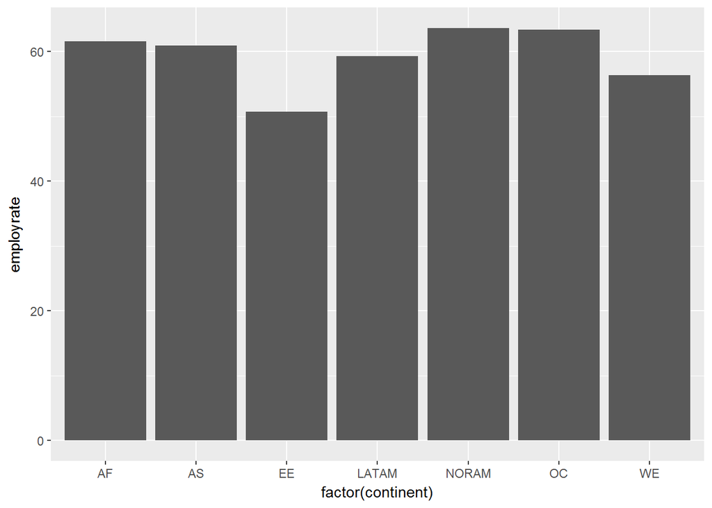

```r
colnames(cemp) <- c("continent", "employrate")
cemp[, 2] <- sapply(cemp[, 2], as.numeric)


library(ggplot2)
ggplot(cemp, aes(x=factor(continent), y=employrate)) + stat_summary(fun.y="mean", geom="bar")
```

- 3.3

```r
ow_anova <- aov(employrate ~ continent, anovac)
summary(ow_anova)
```

```
##              Df Sum Sq Mean Sq F value  Pr(>F)
## continent     6   2302   383.7   3.938 0.00106 **
## Residuals   161  15689    97.4
## ---
## Signif. codes:  0 '***' 0.001 '**' 0.01 '*' 0.05 '.' 0.1 ' ' 1
```

```r
anova(ow_anova)
```

```
## Analysis of Variance Table
##
## Response: employrate
##            Df  Sum Sq Mean Sq F value   Pr(>F)
## continent   6  2302.3  383.72  3.9377 0.001062 **
## Residuals 161 15689.4   97.45
## ---
## Signif. codes:  0 '***' 0.001 '**' 0.01 '*' 0.05 '.' 0.1 ' ' 1
```

```r
confint(ow_anova)
```

```
##                     2.5 %     97.5 %
## (Intercept)     58.967709 64.2250184
## continentAS     -4.914446  3.5160045
## continentEE    -15.818672 -5.9831459
## continentLATAM  -6.875716  2.1758471
## continentNORAM  -9.554477 13.5617492
## continentOC     -8.366903 11.8241778
## continentWE    -10.258968 -0.2575695
```

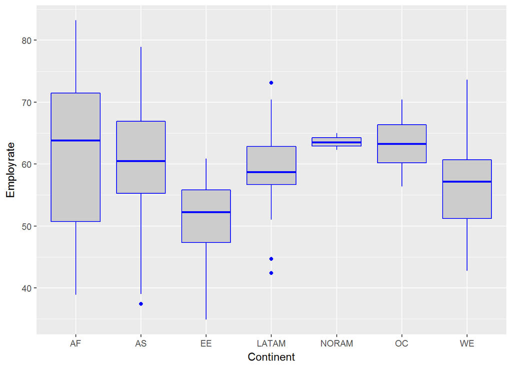

```r
anovafact <- anovac
require(ggplot2)

ggplot(anovafact, aes(x = continent, y = employrate)) +
  geom_boxplot(fill = "grey80", colour = "blue") +
  scale_x_discrete() + xlab("Continent") +
  ylab("Employrate")
```

```r
anovamod <- aov(employrate ~ continent, anovafact)
anovamod
```

```
## Call:
##    aov(formula = employrate ~ continent, data = anovafact)
##
## Terms:
##                 continent Residuals
## Sum of Squares   2302.335 15689.385
## Deg. of Freedom         6       161
##
## Residual standard error: 9.871656
## Estimated effects may be unbalanced
```

```r
summary(anovamod)
```

```
##              Df Sum Sq Mean Sq F value  Pr(>F)
## continent     6   2302   383.7   3.938 0.00106 **
## Residuals   161  15689    97.4
## ---
## Signif. codes:  0 '***' 0.001 '**' 0.01 '*' 0.05 '.' 0.1 ' ' 1
```

```r
anova(anovamod)
```

```
## Analysis of Variance Table
##
## Response: employrate
##            Df  Sum Sq Mean Sq F value   Pr(>F)
## continent   6  2302.3  383.72  3.9377 0.001062 **
## Residuals 161 15689.4   97.45
## ---
## Signif. codes:  0 '***' 0.001 '**' 0.01 '*' 0.05 '.' 0.1 ' ' 1
```

```r
confint(anovamod)
```

```
##                     2.5 %     97.5 %
## (Intercept)     58.967709 64.2250184
## continentAS     -4.914446  3.5160045
## continentEE    -15.818672 -5.9831459
## continentLATAM  -6.875716  2.1758471
## continentNORAM  -9.554477 13.5617492
## continentOC     -8.366903 11.8241778
## continentWE    -10.258968 -0.2575695
```

F value is 3.938, and p-value is very low too. This means tha the variation of employrate means among different continents is much larger than the variation of employrate within each continents, and our p-value is less than 0.05 (as suggested by normal scientific standard). Hence we can conclude that for our confidence interval we accept the alternative hypothesis H1 that there is a significant relationship between continents and employrate.

- 3.4

Not all means are equal. Tukey test is designed to evaluate pair means.

```r
tuk<- TukeyHSD(anovamod)
tuk
```

```
##   Tukey multiple comparisons of means
##     95% family-wise confidence level
##
## Fit: aov(formula = employrate ~ continent, data = anovafact)
##
## $continent
##                    diff         lwr       upr     p adj
## AS-AF        -0.6992209  -7.0727955  5.674354 0.9998981
## EE-AF       -10.9009089 -18.3367459 -3.465072 0.0004246
## LATAM-AF     -2.3499345  -9.1930816  4.493213 0.9474835
## NORAM-AF      2.0036362 -15.4726526 19.479925 0.9998682
## OC-AF         1.7286372 -13.5361886 16.993463 0.9998773
## WE-AF        -5.2582686 -12.8195080  2.302971 0.3716459
## EE-AS       -10.2016880 -18.2215935 -2.181782 0.0038148
## LATAM-AS     -1.6507136  -9.1243924  5.822965 0.9945218
## NORAM-AS      2.7028571 -15.0298213 20.435535 0.9993138
## OC-AS         2.4278581 -13.1298448 17.985561 0.9992148
## WE-AS        -4.5590477 -12.6953585  3.577263 0.6348775
## LATAM-EE      8.5509744   0.1530524 16.948896 0.0429728
## NORAM-EE     12.9045451  -5.2370398 31.046130 0.3437156
## OC-EE        12.6295461  -3.3926678 28.651760 0.2255017
## WE-EE         5.6426403  -3.3500664 14.635347 0.5008001
## NORAM-LATAM   4.3535707 -13.5532462 22.260388 0.9908143
## OC-LATAM      4.0785717 -11.6773265 19.834470 0.9872053
## WE-LATAM     -2.9083341 -11.4174916  5.600824 0.9486353
## OC-NORAM     -0.2749990 -22.7881137 22.238116 1.0000000
## WE-NORAM     -7.2619048 -25.4552489 10.931439 0.8963741
## WE-OC        -6.9869058 -23.0677020  9.093890 0.8523143
```

From the table above (looking at “diff” and “p adj” columns) I can see which continents have significant differences in eployrate from others. For example I can conclude that:

There is no significant difference in employrate between Asia and Africa etc where p adj =0.99 > 0.05.

There is significant difference in employrate between East Europe and Africa etc where p<<0.05.

Next step is visualizing the differences between means in each continent. Significant differences are the ones that do not cross the zero value.

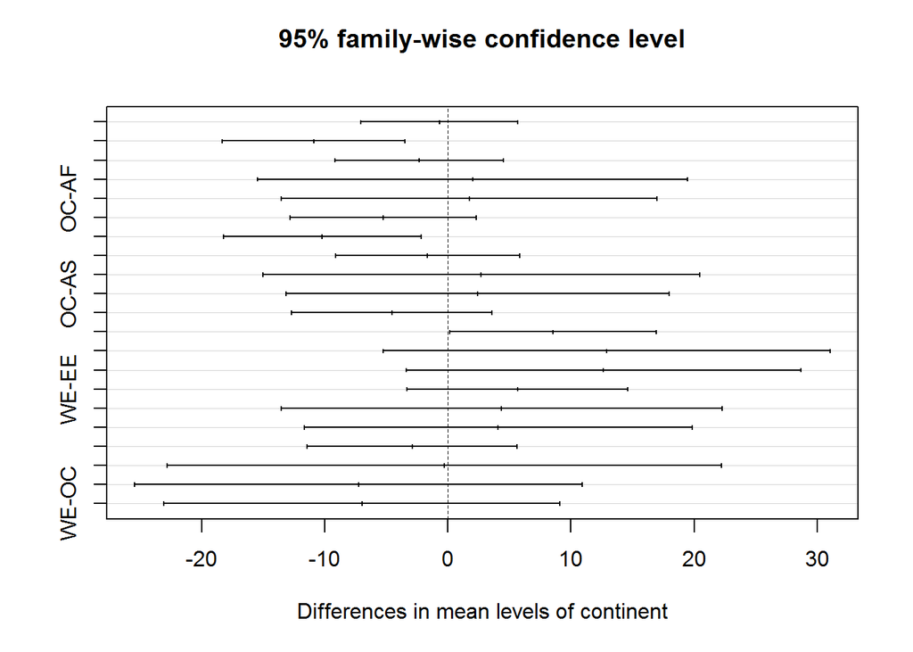

```r
plot (tuk)
```

- 3.5

Bartlett’s test will be used to determine whether the variance in employrate is the same for all continents. A significance level of 0.05 will be used.

```r
bartlett.test(employrate ~ continent, data=anovac)
```

```
##
##  Bartlett test of homogeneity of variances
##
## data:  employrate by continent
## Bartlett's K-squared = 29.098, df = 6, p-value = 5.829e-05
```

I will also use fligner test to determine whether the the variance in employrate is the same for all continents. The null hypothesis is once more that all of the variances are equal.

```r
fligner.test(employrate ~ continent, data=anovac)
```

```
##
##  Fligner-Killeen test of homogeneity of variances
##
## data:  employrate by continent
## Fligner-Killeen:med chi-squared = 27.52, df = 6, p-value =
## 0.0001157
```

From the output of both 2 tests we can see that the p-value<< 0.05. This means we can assume the alternative H1 hypothesis that the variance is not the same for all continents. This means that there is evidence to suggest that the variance in employrate is different for each continent.

- 3.6

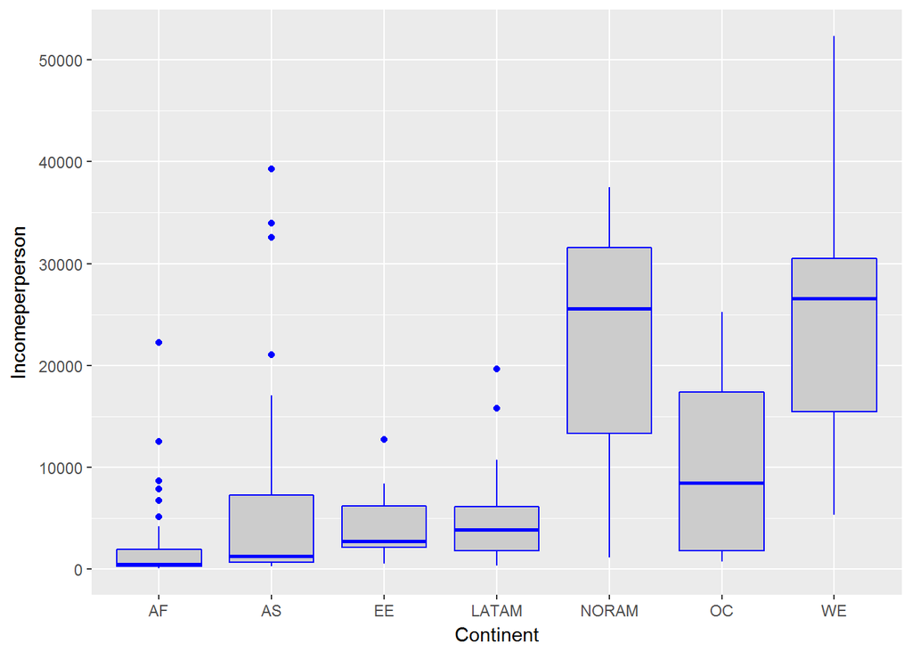

```r
ggplot(anovafact, aes(x = continent, y = incomeperperson)) +
  geom_boxplot(fill = "grey80", colour = "blue") +
  scale_x_discrete() + xlab("Continent") +
  ylab("Incomeperperson")
```

Although EE has low average income, the dispersion and therefore the wealth gap is not wide. In contrast NORAM and WE, continents with much higher average incomes have dramatically higher economic inequality.

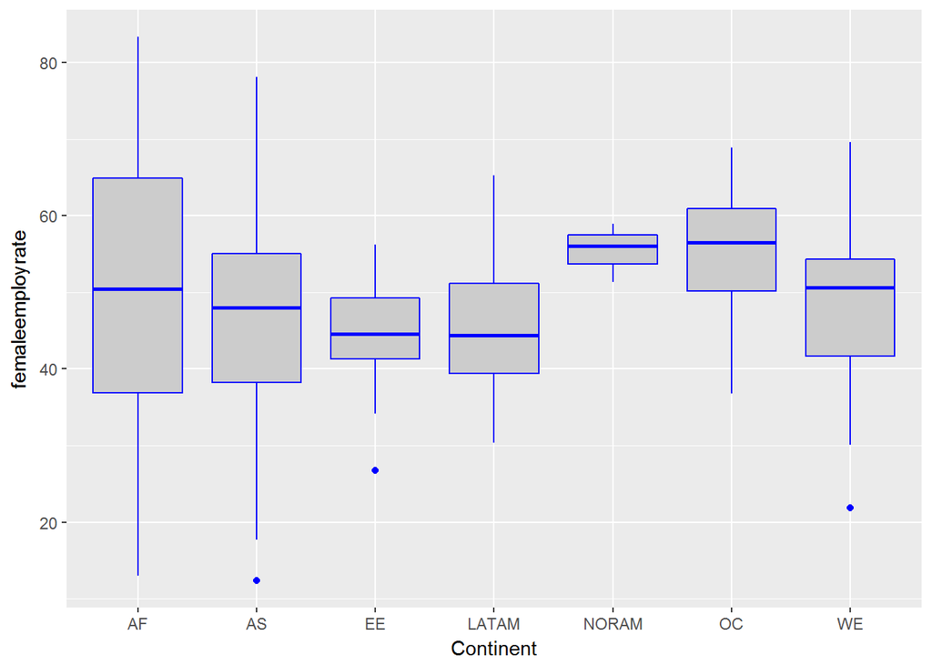

```r
  ggplot(anovafact, aes(x = continent, y = femaleemployrate)) +
  geom_boxplot(fill = "grey80", colour = "blue") +
  scale_x_discrete() + xlab("Continent") +
  ylab("femaleemployrate")
```

Female employment rate is low in EE.

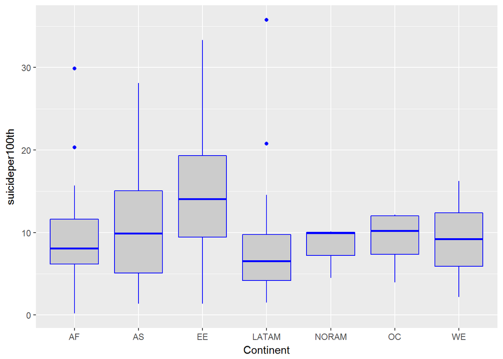

```r
   ggplot(anovafact, aes(x = continent, y = suicideper100th)) +
  geom_boxplot(fill = "grey80", colour = "blue") +
  scale_x_discrete() + xlab("Continent") +
  ylab("suicideper100th")
```

EE has the highest number of suicides comparing to the other continents.

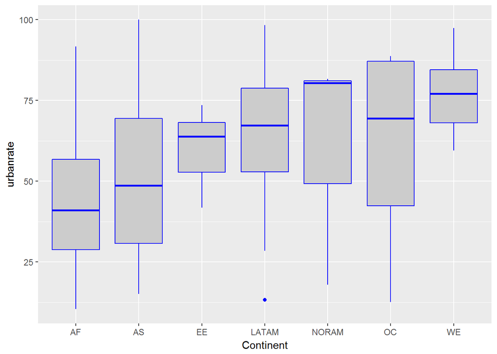

```r
     ggplot(anovafact, aes(x = continent, y = urbanrate)) +
  geom_boxplot(fill = "grey80", colour = "blue") +
  scale_x_discrete() + xlab("Continent") +
  ylab("urbanrate")
```

Although we have gained some interesting insights, this model misses important variables and therefore we cannot draw concrete conclusions.

For example employment rate depends on other factors as well such as education, economic and political stability, family wealth etc.

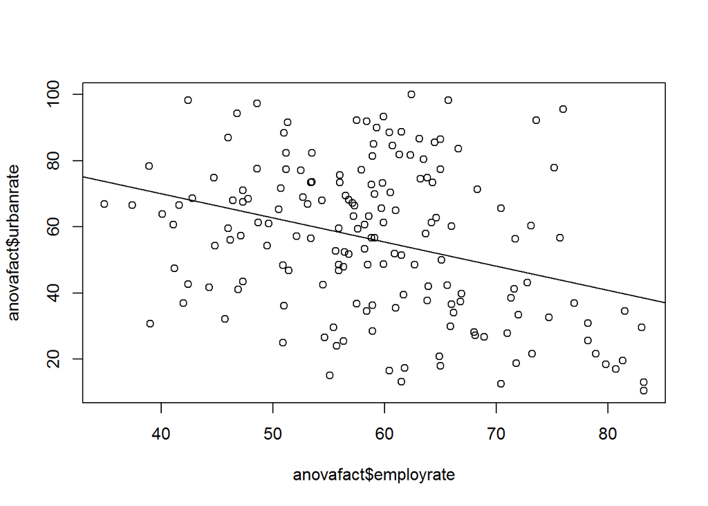

```r
plot(anovafact$urbanrate~anovafact$employrate)
abline(test <- lm(anovafact$urbanrate~anovafact$employrate, data = anovafact))
```

This graph makes it clear that there is a negative correlation between urbanrization and employment rate.

## Question 4

- 4.1

```r
housing <- read.table("./housing.data", quote="\"", comment.char="")
```

- 4.2

```r
colnames(housing) <- c("CRIM", "ZN", "INDUS", "CHAS", "NOX", "RM", "AGE", "DIS",  "RAD", "TAX", "PTRATIO", "B", "LSTAT", "MEDV")
```

- 4.3

```r
model1 <- lm(MEDV ~ ., data = housing)

housing2 <- housing
sapply(housing2,class)
```

```
##      CRIM        ZN     INDUS      CHAS       NOX        RM       AGE
## "numeric" "numeric" "numeric" "integer" "numeric" "numeric" "numeric"
##       DIS       RAD       TAX   PTRATIO         B     LSTAT      MEDV
## "numeric" "integer" "numeric" "numeric" "numeric" "numeric" "numeric"
```

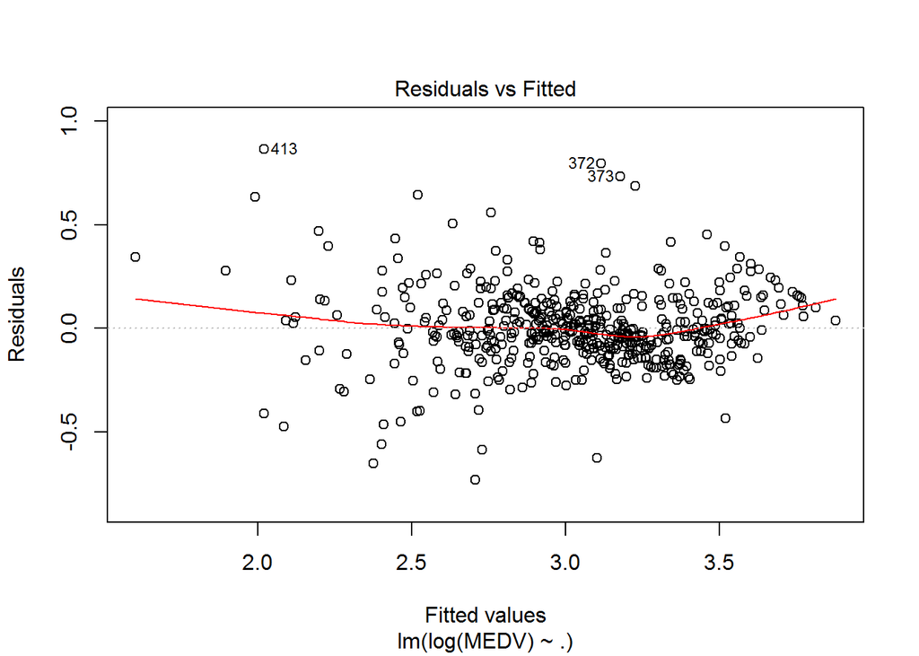

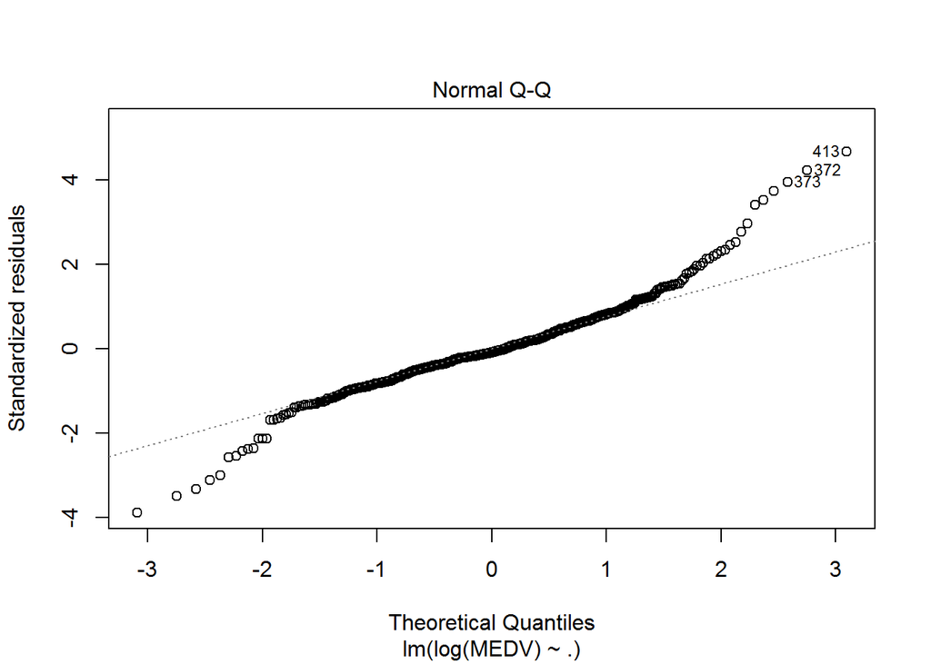

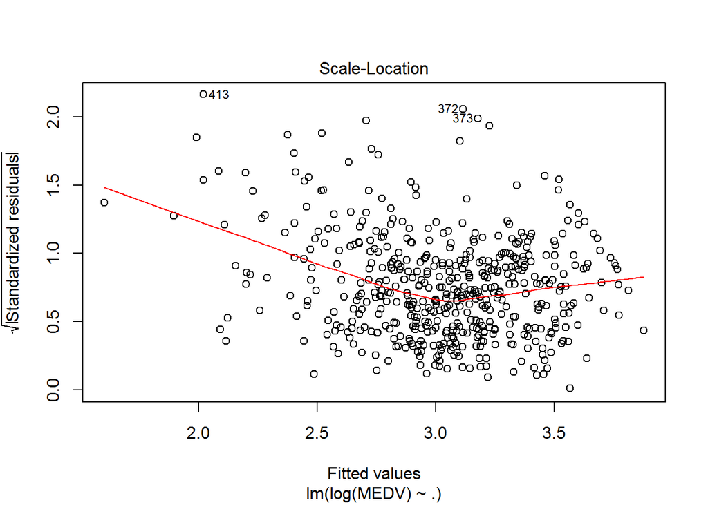

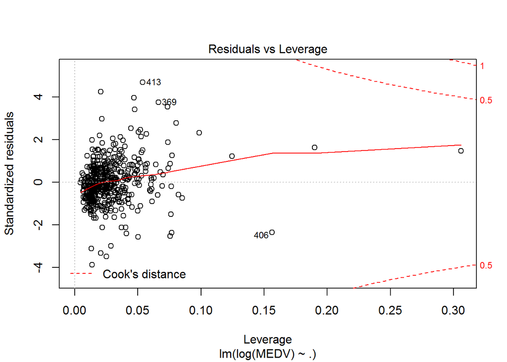

```r
scale2 = scale(housing2[,c( "MEDV")])
housing2[,c("MEDV")] <- scale2
model2 <- lm(MEDV ~ ., data = housing2)
model3 <- lm(log(MEDV) ~ ., data = housing)

plot(model3)
```

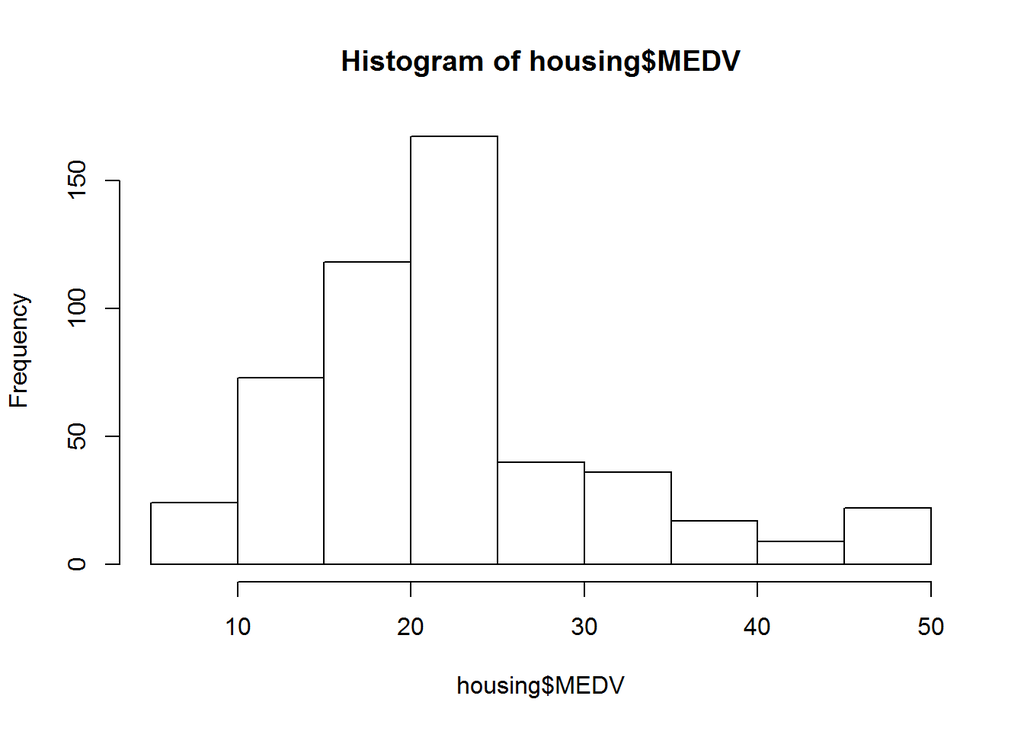

```r
hist(housing$MEDV)
```

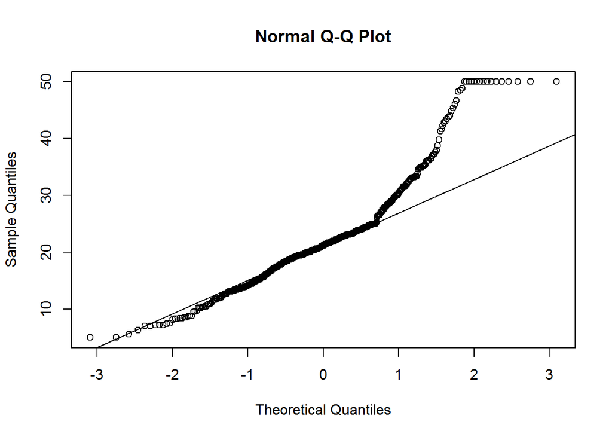

```r
qqnorm(housing$MEDV)
qqline(housing$MEDV)
```

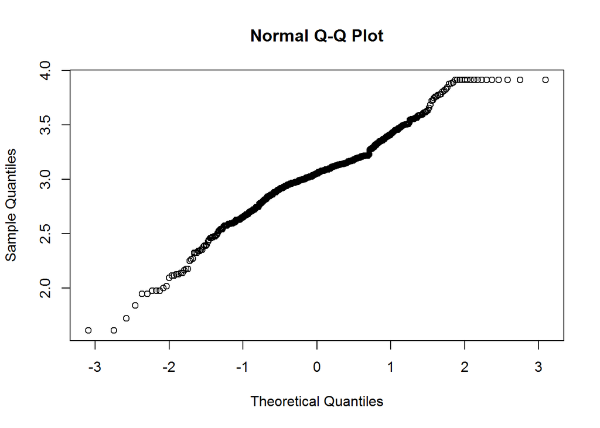

```r
#log(medv) improves things
qqnorm(log(housing$MEDV))
```

```r
model1 <- lm(log(MEDV) ~ ., data = housing)
summary(model1)
```

```
##
## Call:
## lm(formula = log(MEDV) ~ ., data = housing)
##
## Residuals:
##      Min       1Q   Median       3Q      Max
## -0.73361 -0.09747 -0.01657  0.09629  0.86435
##
## Coefficients:
##               Estimate Std. Error t value Pr(>|t|)
## (Intercept)  4.1020423  0.2042726  20.081  < 2e-16 ***
## CRIM        -0.0102715  0.0013155  -7.808 3.52e-14 ***
## ZN           0.0011725  0.0005495   2.134 0.033349 *
## INDUS        0.0024668  0.0024614   1.002 0.316755
## CHAS         0.1008876  0.0344859   2.925 0.003598 **
## NOX         -0.7783993  0.1528902  -5.091 5.07e-07 ***
## RM           0.0908331  0.0167280   5.430 8.87e-08 ***
## AGE          0.0002106  0.0005287   0.398 0.690567
## DIS         -0.0490873  0.0079834  -6.149 1.62e-09 ***
## RAD          0.0142673  0.0026556   5.373 1.20e-07 ***
## TAX         -0.0006258  0.0001505  -4.157 3.80e-05 ***
## PTRATIO     -0.0382715  0.0052365  -7.309 1.10e-12 ***
## B            0.0004136  0.0001075   3.847 0.000135 ***
## LSTAT       -0.0290355  0.0020299 -14.304  < 2e-16 ***
## ---
## Signif. codes:  0 '***' 0.001 '**' 0.01 '*' 0.05 '.' 0.1 ' ' 1
##
## Residual standard error: 0.1899 on 492 degrees of freedom
## Multiple R-squared:  0.7896, Adjusted R-squared:  0.7841
## F-statistic: 142.1 on 13 and 492 DF,  p-value: < 2.2e-16
```

```r
model2 <- lm(log(MEDV) ~. -INDUS -AGE, data = housing)
summary(model2)
```

```
##
## Call:
## lm(formula = log(MEDV) ~ . - INDUS - AGE, data = housing)
##
## Residuals:
##      Min       1Q   Median       3Q      Max
## -0.73400 -0.09460 -0.01771  0.09782  0.86290
##
## Coefficients:
##               Estimate Std. Error t value Pr(>|t|)
## (Intercept)  4.0836823  0.2030491  20.112  < 2e-16 ***
## CRIM        -0.0103187  0.0013134  -7.856 2.49e-14 ***
## ZN           0.0010874  0.0005418   2.007 0.045308 *
## CHAS         0.1051484  0.0342285   3.072 0.002244 **
## NOX         -0.7217440  0.1416535  -5.095 4.97e-07 ***
## RM           0.0906728  0.0162807   5.569 4.20e-08 ***
## DIS         -0.0517059  0.0074420  -6.948 1.18e-11 ***
## RAD          0.0134457  0.0025405   5.293 1.82e-07 ***
## TAX         -0.0005579  0.0001351  -4.129 4.28e-05 ***
## PTRATIO     -0.0374259  0.0051715  -7.237 1.77e-12 ***
## B            0.0004127  0.0001071   3.852 0.000133 ***
## LSTAT       -0.0286039  0.0019002 -15.053  < 2e-16 ***
## ---
## Signif. codes:  0 '***' 0.001 '**' 0.01 '*' 0.05 '.' 0.1 ' ' 1
##
## Residual standard error: 0.1898 on 494 degrees of freedom
## Multiple R-squared:  0.7891, Adjusted R-squared:  0.7844
## F-statistic: 168.1 on 11 and 494 DF,  p-value: < 2.2e-16
```

```r
library(car)
vif(model2)
```

```
##     CRIM       ZN     CHAS      NOX       RM      DIS      RAD      TAX
## 1.789704 2.239229 1.059819 3.778011 1.834806 3.443420 6.861126 7.272386
##  PTRATIO        B    LSTAT
## 1.757681 1.341559 2.581984
```

```r
#There are multicollinearity issues TAX>5

cor(housing)
```

```
##                CRIM          ZN       INDUS         CHAS         NOX
## CRIM     1.00000000 -0.20046922  0.40658341 -0.055891582  0.42097171
## ZN      -0.20046922  1.00000000 -0.53382819 -0.042696719 -0.51660371
## INDUS    0.40658341 -0.53382819  1.00000000  0.062938027  0.76365145
## CHAS    -0.05589158 -0.04269672  0.06293803  1.000000000  0.09120281
## NOX      0.42097171 -0.51660371  0.76365145  0.091202807  1.00000000
## RM      -0.21924670  0.31199059 -0.39167585  0.091251225 -0.30218819
## AGE      0.35273425 -0.56953734  0.64477851  0.086517774  0.73147010
## DIS     -0.37967009  0.66440822 -0.70802699 -0.099175780 -0.76923011
## RAD      0.62550515 -0.31194783  0.59512927 -0.007368241  0.61144056
## TAX      0.58276431 -0.31456332  0.72076018 -0.035586518  0.66802320
## PTRATIO  0.28994558 -0.39167855  0.38324756 -0.121515174  0.18893268
## B       -0.38506394  0.17552032 -0.35697654  0.048788485 -0.38005064
## LSTAT    0.45562148 -0.41299457  0.60379972 -0.053929298  0.59087892
## MEDV    -0.38830461  0.36044534 -0.48372516  0.175260177 -0.42732077
##                  RM         AGE         DIS          RAD         TAX
## CRIM    -0.21924670  0.35273425 -0.37967009  0.625505145  0.58276431
## ZN       0.31199059 -0.56953734  0.66440822 -0.311947826 -0.31456332
## INDUS   -0.39167585  0.64477851 -0.70802699  0.595129275  0.72076018
## CHAS     0.09125123  0.08651777 -0.09917578 -0.007368241 -0.03558652
## NOX     -0.30218819  0.73147010 -0.76923011  0.611440563  0.66802320
## RM       1.00000000 -0.24026493  0.20524621 -0.209846668 -0.29204783
## AGE     -0.24026493  1.00000000 -0.74788054  0.456022452  0.50645559
## DIS      0.20524621 -0.74788054  1.00000000 -0.494587930 -0.53443158
## RAD     -0.20984667  0.45602245 -0.49458793  1.000000000  0.91022819
## TAX     -0.29204783  0.50645559 -0.53443158  0.910228189  1.00000000
## PTRATIO -0.35550149  0.26151501 -0.23247054  0.464741179  0.46085304
## B        0.12806864 -0.27353398  0.29151167 -0.444412816 -0.44180801
## LSTAT   -0.61380827  0.60233853 -0.49699583  0.488676335  0.54399341
## MEDV     0.69535995 -0.37695457  0.24992873 -0.381626231 -0.46853593
##            PTRATIO           B      LSTAT       MEDV
## CRIM     0.2899456 -0.38506394  0.4556215 -0.3883046
## ZN      -0.3916785  0.17552032 -0.4129946  0.3604453
## INDUS    0.3832476 -0.35697654  0.6037997 -0.4837252
## CHAS    -0.1215152  0.04878848 -0.0539293  0.1752602
## NOX      0.1889327 -0.38005064  0.5908789 -0.4273208
## RM      -0.3555015  0.12806864 -0.6138083  0.6953599
## AGE      0.2615150 -0.27353398  0.6023385 -0.3769546
## DIS     -0.2324705  0.29151167 -0.4969958  0.2499287
## RAD      0.4647412 -0.44441282  0.4886763 -0.3816262
## TAX      0.4608530 -0.44180801  0.5439934 -0.4685359
## PTRATIO  1.0000000 -0.17738330  0.3740443 -0.5077867
## B       -0.1773833  1.00000000 -0.3660869  0.3334608
## LSTAT    0.3740443 -0.36608690  1.0000000 -0.7376627
## MEDV    -0.5077867  0.33346082 -0.7376627  1.0000000
```

```r
#TAX is higly correlated to CRIM 0.58, INDUS 0.72, NOX 0.66, RAD 0.91 and others
#we will not include TAX in the model
```

```r
model3 <- lm(log(MEDV) ~. -INDUS -AGE -TAX, data = housing)
#summary(model3)
model4 <- lm(log(MEDV) ~. -ZN -INDUS -AGE -TAX, data = housing)
#summary(model4)
#anova(model4)
model5 <- lm(log(MEDV) ~. -RAD -ZN -INDUS -AGE -TAX, data = housing)
#anova(model5)
#anova(model4,model5)
#plot(model5)
model6 <- lm(log(MEDV) ~. -RAD -INDUS -AGE -TAX, data = housing)
#summary(model6)
```

```r
model7 <- lm(MEDV ~. -RAD -INDUS -AGE -TAX, data = housing)
summary(model7)
```

```
##
## Call:
## lm(formula = MEDV ~ . - RAD - INDUS - AGE - TAX, data = housing)
##
## Residuals:
##     Min      1Q  Median      3Q     Max
## -15.803  -2.832  -0.625   1.454  27.766
##
## Coefficients:
##               Estimate Std. Error t value Pr(>|t|)
## (Intercept)  29.507997   4.872538   6.056 2.76e-09 ***
## CRIM         -0.061174   0.030377  -2.014 0.044567 *
## ZN            0.042032   0.013422   3.131 0.001842 **
## CHAS          3.029924   0.868349   3.489 0.000527 ***
## NOX         -16.088513   3.232702  -4.977 8.93e-07 ***
## RM            4.149667   0.407685  10.179  < 2e-16 ***
## DIS          -1.431665   0.188603  -7.591 1.59e-13 ***
## PTRATIO      -0.838640   0.117342  -7.147 3.19e-12 ***
## B             0.008292   0.002688   3.084 0.002153 **
## LSTAT        -0.525004   0.048351 -10.858  < 2e-16 ***
## ---
## Signif. codes:  0 '***' 0.001 '**' 0.01 '*' 0.05 '.' 0.1 ' ' 1
##
## Residual standard error: 4.833 on 496 degrees of freedom
## Multiple R-squared:  0.7288, Adjusted R-squared:  0.7239
## F-statistic: 148.1 on 9 and 496 DF,  p-value: < 2.2e-16
```

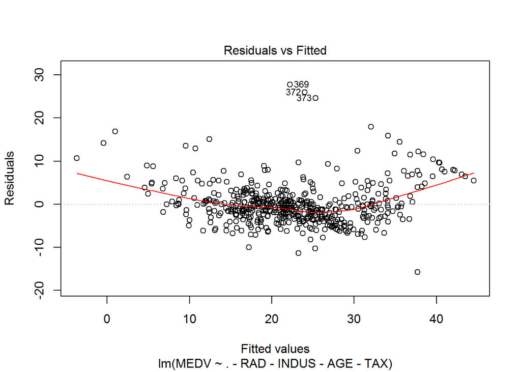

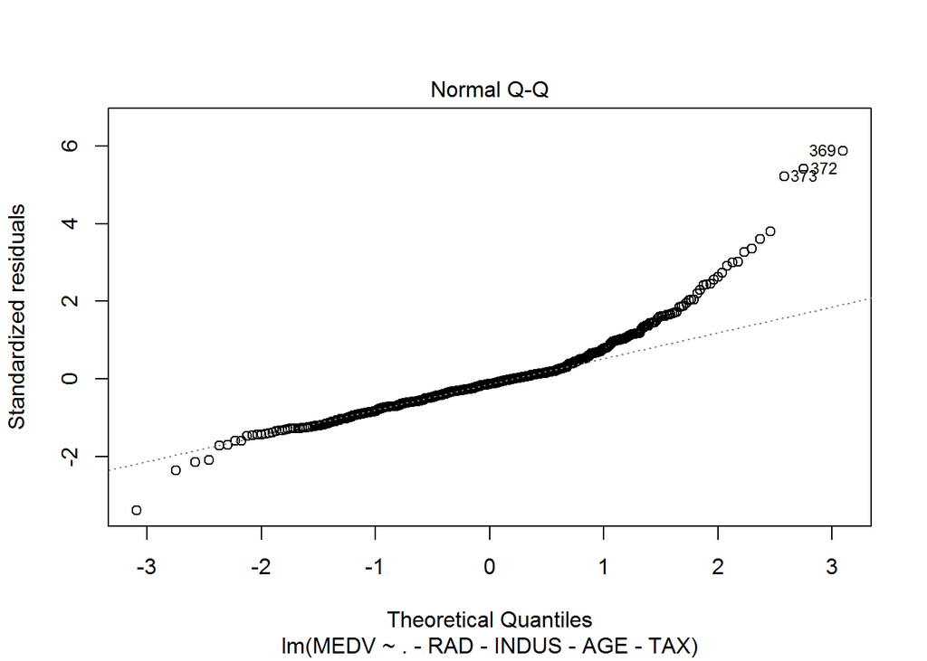

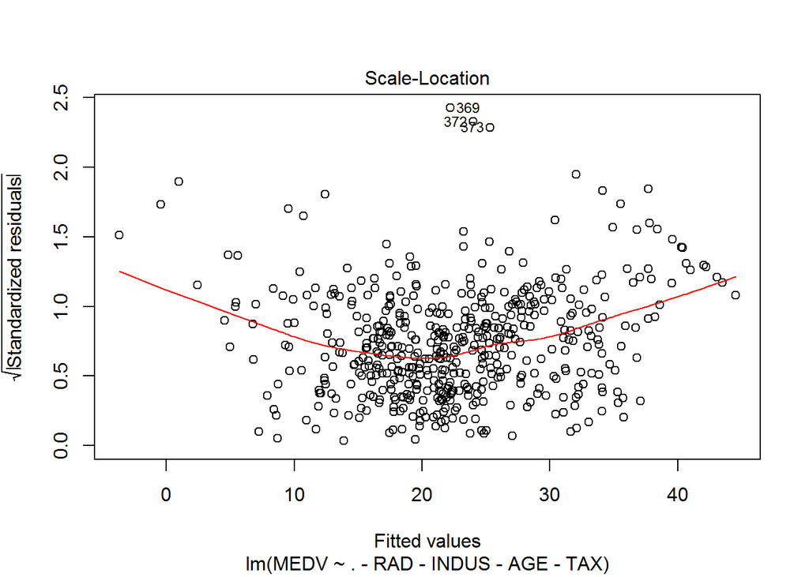

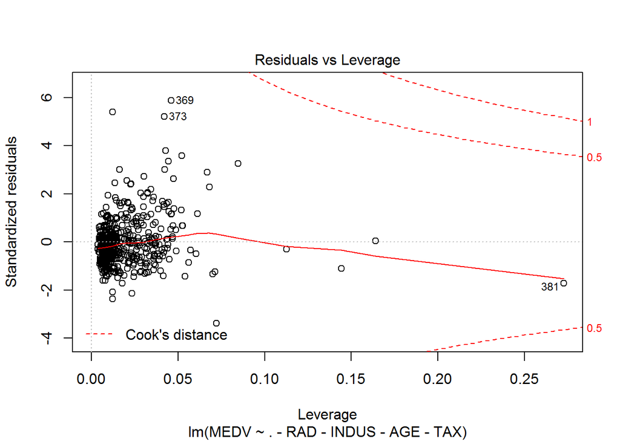

```r
plot(model7)
```

```r
mean(model7$residuals)
```

```
## [1] -2.526902e-16
```

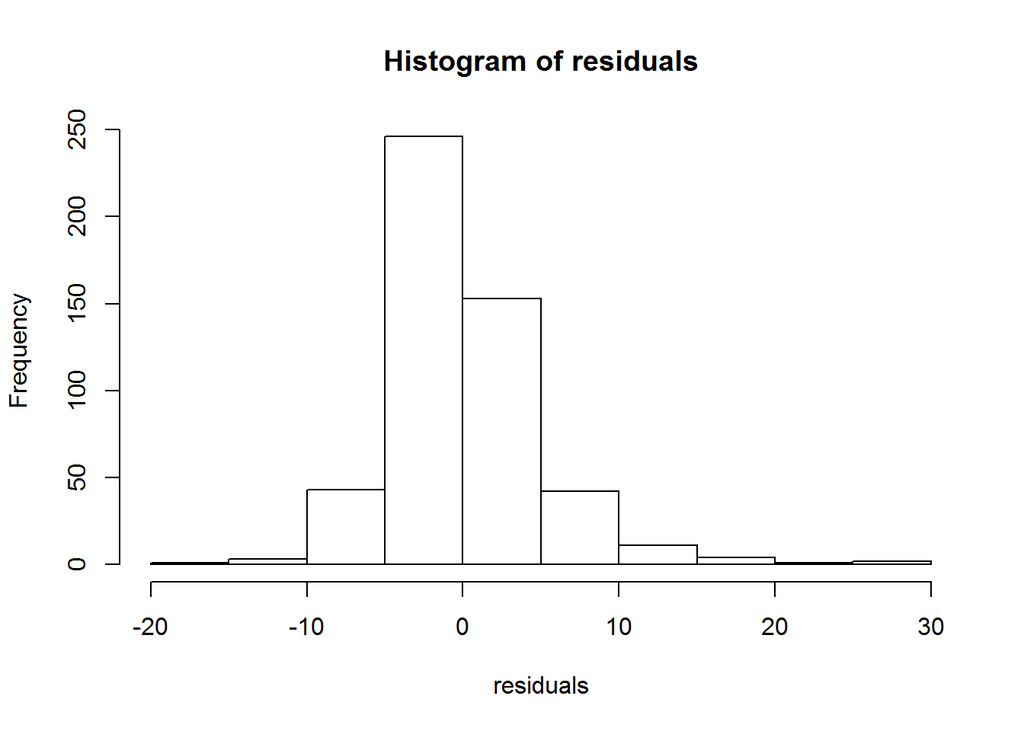

```r
hist(model7$residuals, xlab="residuals", main="Histogram of residuals")
```

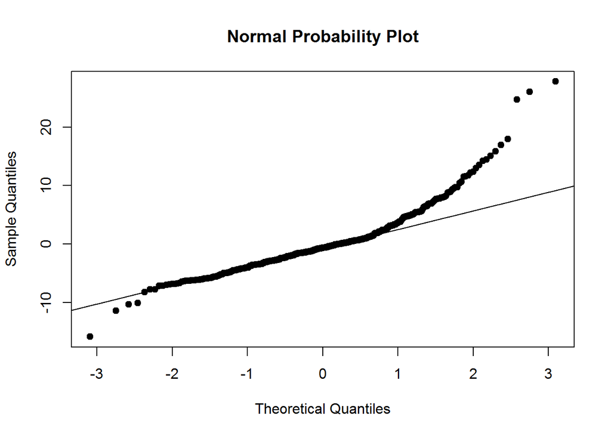

```r
qqnorm(model7$residuals, main="Normal Probability Plot", pch=19)
qqline(model7$residuals)
```

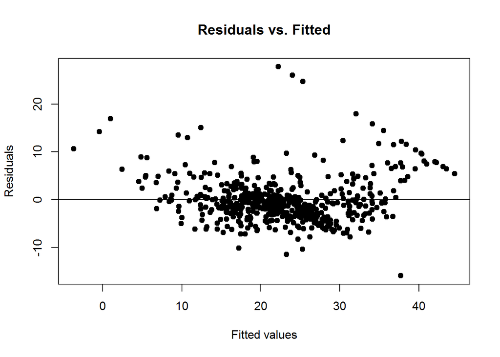

```r
#plot residuals against fitted values (Y-hat)
 plot(model7$fitted.values, model7$residuals, main="Residuals vs. Fitted", xlab="Fitted values", ylab="Residuals", pch=19)
abline(h=0)
```

- 4.4

This model does not fit our data well and we can definitely improve it.

The residuals are the difference between the actual values of the variable MEDV and predicted values from our model. In this case we have high values of residuals.

NOX and cHAS have high standard error of coefficients and we should examine this further. Note: the number error is relevant to the value of the coefficient. HIgher values will have higher errors.

t-values: shows whether whether the coeeficient is meaningful for the model and it is used to calculate the p-value.

P-value is the probability that the variable is not relevant. The lower the better. The stars on the right indicate that it is unlikely that no relationship exists. More stars are better.

Residual standard error: 4.833: This number is the standard deviation of the residuals and it should be proportional to the quantiles of the residuals.

For a normal distribution, the 1st and 3rd quantiles should be 1.5 +/- the std error. In this case is should have been aprox 4.3 instead of 4.8.

R-squared = 72% evaluates the goodness of fit.R-squared should be improved.

- 4.5

F-statistic takes the parameters of our model and compares it to a model that has fewer parameters. In theory the model with more parameters should fit better. High P-value means that our model does not perform better than the model with fewer parameters. Our P-value is really small which means that our model is better than the model with fewer parameters.

- 4.6

The remaining variables are the following LSTAT, RM, PTRATIO, DIS, NOX, CHAS, B, ZN, CRIM

```r
mfull<-lm(MEDV ~. -RAD -INDUS -AGE -TAX, data = housing)
mnull<-lm(MEDV ~1, data = housing)
summary(step(mnull, scope=list(lower=mnull,upper=mfull), direction='both'))
```

```
## Start:  AIC=2246.51
## MEDV ~ 1
##
##           Df Sum of Sq   RSS    AIC
## + LSTAT    1   23243.9 19472 1851.0
## + RM       1   20654.4 22062 1914.2
## + PTRATIO  1   11014.3 31702 2097.6
## + NOX      1    7800.1 34916 2146.5
## + CRIM     1    6440.8 36276 2165.8
## + ZN       1    5549.7 37167 2178.1
## + B        1    4749.9 37966 2188.9
## + DIS      1    2668.2 40048 2215.9
## + CHAS     1    1312.1 41404 2232.7
## <none>                 42716 2246.5
##
## Step:  AIC=1851.01
## MEDV ~ LSTAT
##
##           Df Sum of Sq   RSS    AIC
## + RM       1    4033.1 15439 1735.6
## + PTRATIO  1    2670.1 16802 1778.4
## + CHAS     1     786.3 18686 1832.2
## + DIS      1     772.4 18700 1832.5
## + B        1     198.3 19274 1847.8
## + ZN       1     160.3 19312 1848.8
## + CRIM     1     146.9 19325 1849.2
## <none>                 19472 1851.0
## + NOX      1       4.8 19468 1852.9
## - LSTAT    1   23243.9 42716 2246.5
##
## Step:  AIC=1735.58
## MEDV ~ LSTAT + RM
##
##           Df Sum of Sq   RSS    AIC
## + PTRATIO  1    1711.3 13728 1678.1
## + CHAS     1     548.5 14891 1719.3
## + B        1     512.3 14927 1720.5
## + DIS      1     351.2 15088 1725.9
## + CRIM     1     311.4 15128 1727.3
## <none>                 15439 1735.6
```

[output cut: 94 more lines]

```
##
## Step:  AIC=1604.19
## MEDV ~ LSTAT + RM + PTRATIO + DIS + NOX + CHAS + B + ZN + CRIM
##
##           Df Sum of Sq   RSS    AIC
## <none>                 11584 1604.2
## - CRIM     1     94.71 11678 1606.3
## - B        1    222.18 11806 1611.8
## - ZN       1    229.02 11813 1612.1
## - CHAS     1    284.34 11868 1614.5
## - NOX      1    578.44 12162 1626.8
## - PTRATIO  1   1192.90 12776 1651.8
## - DIS      1   1345.70 12929 1657.8
## - RM       1   2419.57 14003 1698.2
## - LSTAT    1   2753.42 14337 1710.1
```

```
##
## Call:
## lm(formula = MEDV ~ LSTAT + RM + PTRATIO + DIS + NOX + CHAS +
##     B + ZN + CRIM, data = housing)
##
## Residuals:
##     Min      1Q  Median      3Q     Max
## -15.803  -2.832  -0.625   1.454  27.766
##
## Coefficients:
##               Estimate Std. Error t value Pr(>|t|)
## (Intercept)  29.507997   4.872538   6.056 2.76e-09 ***
## LSTAT        -0.525004   0.048351 -10.858  < 2e-16 ***
## RM            4.149667   0.407685  10.179  < 2e-16 ***
## PTRATIO      -0.838640   0.117342  -7.147 3.19e-12 ***
## DIS          -1.431665   0.188603  -7.591 1.59e-13 ***
## NOX         -16.088513   3.232702  -4.977 8.93e-07 ***
## CHAS          3.029924   0.868349   3.489 0.000527 ***
## B             0.008292   0.002688   3.084 0.002153 **
## ZN            0.042032   0.013422   3.131 0.001842 **
## CRIM         -0.061174   0.030377  -2.014 0.044567 *
## ---
## Signif. codes:  0 '***' 0.001 '**' 0.01 '*' 0.05 '.' 0.1 ' ' 1
##
## Residual standard error: 4.833 on 496 degrees of freedom
## Multiple R-squared:  0.7288, Adjusted R-squared:  0.7239
## F-statistic: 148.1 on 9 and 496 DF,  p-value: < 2.2e-16
```

```r
summary(step(mfull, direction='both'))
```

```
## Start:  AIC=1604.19
## MEDV ~ (CRIM + ZN + INDUS + CHAS + NOX + RM + AGE + DIS + RAD +
##     TAX + PTRATIO + B + LSTAT) - RAD - INDUS - AGE - TAX
##
##           Df Sum of Sq   RSS    AIC
## <none>                 11584 1604.2
## - CRIM     1     94.71 11678 1606.3
## - B        1    222.18 11806 1611.8
## - ZN       1    229.02 11813 1612.1
## - CHAS     1    284.34 11868 1614.5
## - NOX      1    578.44 12162 1626.8
## - PTRATIO  1   1192.90 12776 1651.8
## - DIS      1   1345.70 12929 1657.8
## - RM       1   2419.57 14003 1698.2
## - LSTAT    1   2753.42 14337 1710.1
```

```
##
## Call:
## lm(formula = MEDV ~ (CRIM + ZN + INDUS + CHAS + NOX + RM + AGE +
##     DIS + RAD + TAX + PTRATIO + B + LSTAT) - RAD - INDUS - AGE -
##     TAX, data = housing)
##
## Residuals:
##     Min      1Q  Median      3Q     Max
## -15.803  -2.832  -0.625   1.454  27.766
##
## Coefficients:
##               Estimate Std. Error t value Pr(>|t|)
## (Intercept)  29.507997   4.872538   6.056 2.76e-09 ***
## CRIM         -0.061174   0.030377  -2.014 0.044567 *
## ZN            0.042032   0.013422   3.131 0.001842 **
## CHAS          3.029924   0.868349   3.489 0.000527 ***
## NOX         -16.088513   3.232702  -4.977 8.93e-07 ***
## RM            4.149667   0.407685  10.179  < 2e-16 ***
## DIS          -1.431665   0.188603  -7.591 1.59e-13 ***
## PTRATIO      -0.838640   0.117342  -7.147 3.19e-12 ***
## B             0.008292   0.002688   3.084 0.002153 **
## LSTAT        -0.525004   0.048351 -10.858  < 2e-16 ***
## ---
## Signif. codes:  0 '***' 0.001 '**' 0.01 '*' 0.05 '.' 0.1 ' ' 1
##
## Residual standard error: 4.833 on 496 degrees of freedom
## Multiple R-squared:  0.7288, Adjusted R-squared:  0.7239
## F-statistic: 148.1 on 9 and 496 DF,  p-value: < 2.2e-16
```

```r
model8 <- lm(MEDV ~ LSTAT + RM + PTRATIO + DIS + NOX + CHAS +
    B + ZN + CRIM, data = housing)
summary(model8)
```

```
##
## Call:
## lm(formula = MEDV ~ LSTAT + RM + PTRATIO + DIS + NOX + CHAS +
##     B + ZN + CRIM, data = housing)
##
## Residuals:
##     Min      1Q  Median      3Q     Max
## -15.803  -2.832  -0.625   1.454  27.766
##
## Coefficients:
##               Estimate Std. Error t value Pr(>|t|)
## (Intercept)  29.507997   4.872538   6.056 2.76e-09 ***
## LSTAT        -0.525004   0.048351 -10.858  < 2e-16 ***
## RM            4.149667   0.407685  10.179  < 2e-16 ***
## PTRATIO      -0.838640   0.117342  -7.147 3.19e-12 ***
## DIS          -1.431665   0.188603  -7.591 1.59e-13 ***
## NOX         -16.088513   3.232702  -4.977 8.93e-07 ***
## CHAS          3.029924   0.868349   3.489 0.000527 ***
## B             0.008292   0.002688   3.084 0.002153 **
## ZN            0.042032   0.013422   3.131 0.001842 **
## CRIM         -0.061174   0.030377  -2.014 0.044567 *
## ---
## Signif. codes:  0 '***' 0.001 '**' 0.01 '*' 0.05 '.' 0.1 ' ' 1
##
## Residual standard error: 4.833 on 496 degrees of freedom
## Multiple R-squared:  0.7288, Adjusted R-squared:  0.7239
## F-statistic: 148.1 on 9 and 496 DF,  p-value: < 2.2e-16
```

```r
summary(mfull)
```

```
##
## Call:
## lm(formula = MEDV ~ . - RAD - INDUS - AGE - TAX, data = housing)
##
## Residuals:
##     Min      1Q  Median      3Q     Max
## -15.803  -2.832  -0.625   1.454  27.766
##
## Coefficients:
##               Estimate Std. Error t value Pr(>|t|)
## (Intercept)  29.507997   4.872538   6.056 2.76e-09 ***
## CRIM         -0.061174   0.030377  -2.014 0.044567 *
## ZN            0.042032   0.013422   3.131 0.001842 **
## CHAS          3.029924   0.868349   3.489 0.000527 ***
## NOX         -16.088513   3.232702  -4.977 8.93e-07 ***
## RM            4.149667   0.407685  10.179  < 2e-16 ***
## DIS          -1.431665   0.188603  -7.591 1.59e-13 ***
## PTRATIO      -0.838640   0.117342  -7.147 3.19e-12 ***
## B             0.008292   0.002688   3.084 0.002153 **
## LSTAT        -0.525004   0.048351 -10.858  < 2e-16 ***
## ---
## Signif. codes:  0 '***' 0.001 '**' 0.01 '*' 0.05 '.' 0.1 ' ' 1
##
## Residual standard error: 4.833 on 496 degrees of freedom
## Multiple R-squared:  0.7288, Adjusted R-squared:  0.7239
## F-statistic: 148.1 on 9 and 496 DF,  p-value: < 2.2e-16
```

- 4.7

Coefficient of CRIM= -0.061174

- 4.8

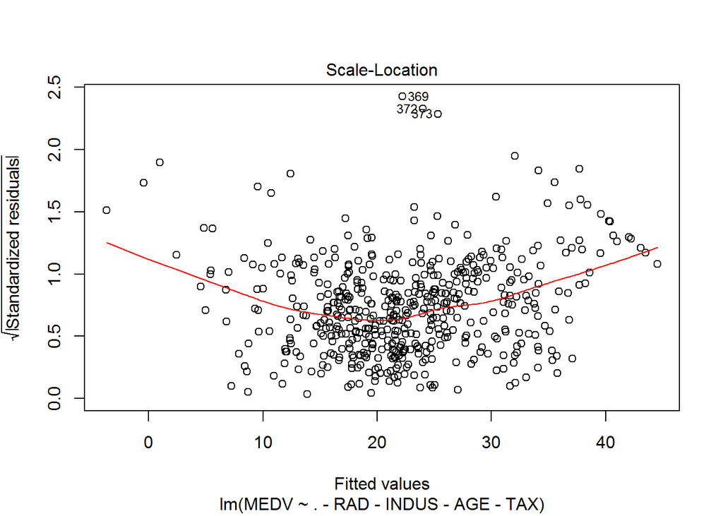

```r
plot(mfull, 3)
```

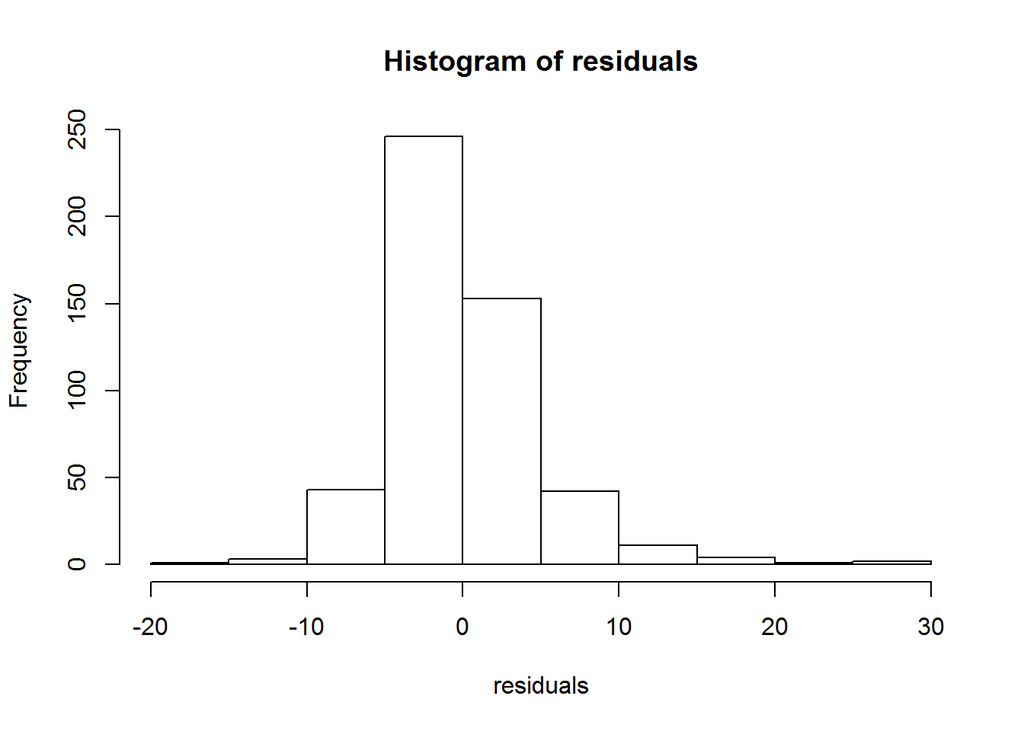

```r
residuals <- mfull$residuals
fitted_values <- mfull$fitted.values
train_ids <- rownames(mfull)
large_residuals <- ifelse(abs(residuals) > 150,train_ids,'')
hist(residuals)
```

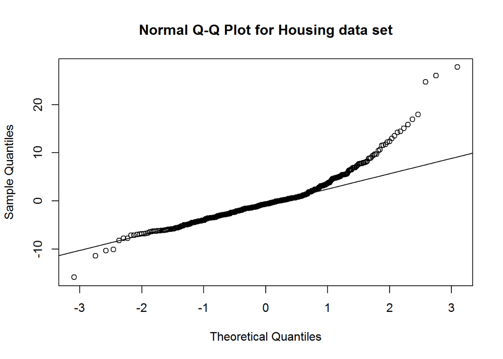

```r
library(ggplot2)


par(mfrow=c(1,1))
qqnorm(residuals, main = "Normal Q-Q Plot for Housing data set")
qqline(residuals)
```

The model’s residuals must be normally distributed and equally spread. In our case the residuals are not normally distributed. There are many extreme positive and few negative residuals. The distribution is “heavy tailed.” Positive values for the residual (on the y-axis) mean the prediction was too low, negative values mean the prediction was too high and 0 means the guess was exactly correct.The relationship between the sample percentiles and theoretical percentiles is not linear.

Concluding, there might be a non-linear relationship between predictor variables and an outcome variable and we can problbly improve our model by adding logarithmic or exponential terms. Removing the outliers may also improve our model.

# check for outliers

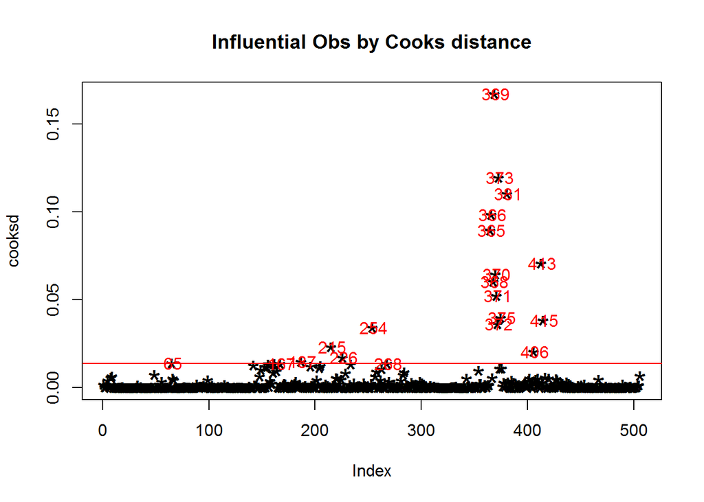

```r
cooksd <- cooks.distance(mfull)
#we clearly have outliers
plot(cooksd, pch="*", cex=2, main="Influential Obs by Cooks distance")  # plot cook's distance
abline(h = 4*mean(cooksd, na.rm=T), col="red")  # add cutoff line
text(x=1:length(cooksd)+1, y=cooksd, labels=ifelse(cooksd>4*mean(cooksd, na.rm=T),names(cooksd),""), col="red")
```

```r
influential <- as.numeric(names(cooksd)[(cooksd > 4*mean(cooksd, na.rm=T))])  # influential row numbers
head(housing[influential, ])
```

```
##        CRIM   ZN INDUS CHAS    NOX    RM  AGE    DIS RAD TAX PTRATIO
## 65  0.01951 17.5  1.38    0 0.4161 7.104 59.5 9.2229   3 216    18.6
## 167 2.01019  0.0 19.58    0 0.6050 7.929 96.2 2.0459   5 403    14.7
## 187 0.05602  0.0  2.46    0 0.4880 7.831 53.6 3.1992   3 193    17.8
## 215 0.28955  0.0 10.59    0 0.4890 5.412  9.8 3.5875   4 277    18.6
## 226 0.52693  0.0  6.20    0 0.5040 8.725 83.0 2.8944   8 307    17.4
## 254 0.36894 22.0  5.86    0 0.4310 8.259  8.4 8.9067   7 330    19.1
##          B LSTAT MEDV
## 65  393.24  8.05 33.0
## 167 369.30  3.70 50.0
## 187 392.63  4.45 50.0
## 215 348.93 29.55 23.7
## 226 382.00  4.63 50.0
## 254 396.90  3.54 42.8
```